# AI for Survey Researchers · Workshop 1

How large language models work. Click a slide to present from there.

[figure not shown]

Workshop 1 of 3

# AI for Survey Researchers

How large language models work

When you type a prompt, what is actually happening?

Paulo Serôdio · ISER, University of Essex

THE MODEL, ONE TOKEN AT A TIME

Model

next token: **<end>**

**Why we are here**

## There are two ways to get LLMs wrong in research

CREDULOUS USE

### “We used ChatGPT to code the responses.”

Paste data into a chat app, accept the answer, report the results. No record of the instrument, no validation, no idea where the data went.

REFLEXIVE DISMISSAL

### “It's just autocomplete. It can't do real research work.”

Ruled out after one unhelpful chat session, while the evidence shows it matches trained coders on many well-specified tasks.

Treat it as an instrument: specify · constrain · validate · report

Both mistakes come from not knowing what the model is. That is today.

01 What an LLM is02 Training03 Where models run04 Interacting05 Reproducibility

02

**Why we are here**

## Turning a request written in plain language into a specified instrument

SURVEY RESEARCH

LLM PIPELINE

Question wording

prompt, verbatim

Codebook · response categories

output schema

Fieldwork protocol

model · version · host · settings

Coder reliability

run-to-run agreement

Validation against a gold standard

evaluation against human coding

Methods section

the log of every call

Plain language goes in; we add the structure that makes it a method.

01 What an LLM is02 Training03 Where models run04 Interacting05 Reproducibility

03

**Today** · 09:30–13:30

## Outline

01

What an LLM is

Tokens in, probabilities out. It only ever produces text.

02

Training

Every training stage leaves a mark on your outputs.

03

Where models run

Hosts, data, quantisation, cost.

04

Interacting

Chat, API, structured outputs, reasoning, agents.

05

Reproducibility

What varies, what to measure, what to report.

When you type a prompt, what is happening?

01 What an LLM is02 Training03 Where models run04 Interacting05 Reproducibility

04

**Poll** · Zoom poll or chat

Which is closest to how you use LLMs in your research today?

ANot at all

BA chat app, for writing, reading or admin

CA chat app, on research data (coding, summarising, classifying)

DThrough an API or code

01 What an LLM is02 Training03 Where models run04 Interacting05 Reproducibility

05

**Why we are here** · the evidence

## LLMs already do real social-science work, often close to human coders

Coding open-ended survey answers

93.9%

agreement with the original coder; a second human: 94.7%

BES “most important issue” · Mellon et al. 2024

Annotating political text

+25 pts

accuracy over crowd-workers, about 30× cheaper

Gilardi, Alizadeh & Kubli, PNAS 2023

Coding ideology of tweets

85%

agreement with experts; human coders with each other: 85%

Heseltine & Clemm von Hohenberg 2024

Predicting survey experiments

r = 0.85

with real effects across 70 experiments (0.90 for unpublished ones)

Ashokkumar et al., Nature 2026

Appraising questions (QAS-99)

63%

agreement with an expert; a novice with the expert: 64%

Roberts et al. 2026 · Survey Futures WP22

Models: Claude 1.3; GPT 3.5 Turbo; GPT 4; Sonnet;

01 What an LLM is02 Training03 Where models run04 Interacting05 Reproducibility

06 · Mellon et al. 2024 · Gilardi et al. 2023 · Heseltine & Clemm von Hohenberg 2024 · Ashokkumar et al. 2026 · Roberts et al. 2026

**Why we are here** · the evidence

## How did the models perform and why?

### WHERE IT HOLDS UP

**Clear, closed categories**a codebook a trained coder could follow

**Short texts**answers, tweets, single statements

**Checked against human coding**every study on the last slide did this

### WHERE IT SLIPS

**Rare and residual codes**“other” and “no reason”: F1 of 0.02–0.3 out of the box

**Long texts**full news articles: accuracy fell to 76–80%

**Sizes and subtle risks**effects ~2× too large; social-desirability risks missed

**0.94–1.00**run-to-run ICC

The model gave the same codes when asked again: **reliable**.

**≈ 0.7**macro-F1 vs human codes

Out of the box, many of those codes were wrong: **not yet valid**.

von der Heyde et al. 2025 · 5,072 German open-ended answers

Model: GPT-4o

01 What an LLM is02 Training03 Where models run04 Interacting05 Reproducibility

07 · von der Heyde et al. 2025 · Heseltine & Clemm von Hohenberg 2024 · Ashokkumar et al. 2026 · Roberts et al. 2026

01

## What an LLM actually is

A function: text in, a probability for every possible next token out. It only ever produces text.

01 What an LLM is02 Training03 Where models run04 Interacting05 Reproducibility

08

**01** What an LLM is · predicting the next word

Predict the next word

Strongly agree · Agree · Neither agree nor disagree

Model

likely next token: disagree

Models predict next tokens.

01 What an LLM is02 Training03 Where models run04 Interacting05 Reproducibility

09

**01** What an LLM is · the whole pipeline

*text**tokens**embeddings**layers**probabilities**pick**append*

Text

Overall, how would you rate the service? I would say it was

Tokens · IDs

Overall*37185*

,*11*

how*1495*

would*1481*

you*481*

rate*6251*

the*290*

service*2570*

?*30*

I*357*

would*1481*

say*2891*

it*480*

was*673*

Embeddings

Layers

layer N

⋮

layer 2

layer 1

Probabilities

good

34%

excellent

20%

fine

14%

okay

10%

…

22%

Pick one

good

Append

…I would say it was  
good

Every chatbot, agent and “AI tool” is this loop plus software around it.

01 What an LLM is02 Training03 Where models run04 Interacting05 Reproducibility

10 · Token IDs computed with tiktoken (o200k_base)

**01** What an LLM is · tokens

## Token = word

*text**tokens**embeddings**layers**probabilities**pick**append*

The interviewer reread the unanswerable questions.

Theinterviewerrereadtheunanswerablequestions.7 tokens

+ advantages

**+**simple

**+**interpretable

− drawbacks

**−**vocabulary must hold every word form (answer, answers, answered, answerable, **unanswerable**…)

**−**does not share the root of words

**−**risk of “out-of-vocabulary” words (mapped to an unknown token)

Words are simple, but the vocabulary must hold every word form.

01 What an LLM is02 Training03 Where models run04 Interacting05 Reproducibility

11 · Counts computed by us with tiktoken (o200k_base)

**01** What an LLM is · tokens

## Token = character

*text**tokens**embeddings**layers**probabilities**pick**append*

The interviewer reread the unanswerable questions.

The␣interviewer␣reread␣th

e␣unanswerable␣questions.

50 tokens · ␣ = space

+ advantages

**+**robust to CASinG and mispelings

**+**small vocabulary (byte-level: 256 possible bytes)

− drawbacks

**−**sequences much longer (50 vs 7)

**−**each token carries little meaning, so the model must learn words from scratch

Characters never fail on unseen words, but sequences become very long.

01 What an LLM is02 Training03 Where models run04 Interacting05 Reproducibility

12 · Counts computed by us with tiktoken (o200k_base)

**01** What an LLM is · tokens

## Token = subword

*text**tokens**embeddings**layers**probabilities**pick**append*

The interviewer reread the unanswerable questions.

The interviewer reread the unanswerable questions.10 tokens

▲ un · answer · able  
shares the root “answer” with answer, answers, answerable…

▲ rere · ad (dashed)  
splits are statistical, not linguistic

+ advantages

**+**leverages roots of words

**+**learned from the data (byte-pair encoding, next slides)

− drawbacks

**−**an extra step: the tokenizer must be trained first

**−**efficiency depends on the training corpus (rarer languages are split into more pieces)

Subwords reuse word roots and keep sequences short; the split is learned.

01 What an LLM is02 Training03 Where models run04 Interacting05 Reproducibility

13 · Counts computed by us with tiktoken (o200k_base)

**01** What an LLM is · tokens

## Vocabulary V and sequence length n

*text**tokens**embeddings**layers**probabilities**pick**append*

The interviewer reread the unanswerable questions.

answer*17021*↔

embedding: a column of d numbers, one row of a V × d table

Vocabulary V  
The*976*  
un*537*  
answer*17021*  
able*5359*  
… 200,019 entries

| Token unit | Vocabulary V | Sequence length n |
| --- | --- | --- |
| word | every word form, very large | n = 7 |
| subword | V = 200,019 (o200k_base) | n = 10 |
| character / byte | V = 256 bytes | n = 50 |

Bigger V, shorter n, bigger embedding table; subwords sit in between.

01 What an LLM is02 Training03 Where models run04 Interacting05 Reproducibility

14 · Counts computed by us with tiktoken (o200k_base)

**01** What an LLM is · tokens

## Text is cut into tokens, and each token is an integer ID

*text**tokens**embeddings**layers**probabilities**pick**append*

How satisfied are you with your local health services?

How*5299**4438* satisfied*23121**20097* are*553**527* you*481**499* with*483**449* your*634**701* local*2698**2254* health*3230**2890* services*3581**3600* ?*30**30*

“ satisfied” = one token, ID 23121.  
“satisfied” without the space = two tokens: s + atisfied.

top number: o200k_base (GPT-4o)  
bottom number: cl100k_base (GPT-4)  
same token, different ID

[Try it: tiktokenizer](https://tiktokenizer.vercel.app/)

Tokens are not words. IDs are lookup keys, not meanings.

01 What an LLM is02 Training03 Where models run04 Interacting05 Reproducibility

15 · Splits and IDs computed with tiktoken: o200k_base (GPT-4o family), cl100k_base (GPT-4)

**01** What an LLM is · tokens

## The same question costs different languages different numbers of tokens

*text**tokens**embeddings**layers**probabilities**pick**append*

cl100k_base (GPT-4)o200k_base (GPT-4o)

× English, old → new

English

10

10

1.0 → 1.0

Welsh

23

13

2.3 → 1.3

Polish

21

19

2.1 → 1.9

Portuguese

14

12

1.4 → 1.2

You pay and fill context per token.

01 What an LLM is02 Training03 Where models run04 Interacting05 Reproducibility

16 · Token counts computed with tiktoken (cl100k_base, o200k_base); translations ours

**01** What an LLM is · tokens

## BPE: the vocabulary is built by merging the most frequent pairs

*text**tokens**embeddings**layers**probabilities**pick**append*

Merges learned

“the cat sat on the mat” as symbols

**11**symbols22 → 11 symbols after 5 merges

**≈ 100k**cl100k_base entries · 100,277

**≈ 200k**o200k_base entries · 200,019

Frequent pieces become single tokens. Rare words are split into more pieces.

01 What an LLM is02 Training03 Where models run04 Interacting05 Reproducibility

17 · Toy merges computed by us in Python · vocabulary sizes: tiktoken n_vocab (cl100k_base 100,277; o200k_base 200,019)

**01** What an LLM is · tokens

## Some odd model behaviour is really tokenisation

*text**tokens**embeddings**layers**probabilities**pick**append*

Counting letters

“how many r in strawberry?”

mid-sentence

strawberry*101830*

start of text

st*302*raw*1618*berry*19772*

Arithmetic

digits arrive in chunks

1234567.89

123*7633*456*19354*7*22*.*13*89*7479*

Scale labels

“ disagree” is its own token

Neither agree nor disagree

Neither*153247* agree*10758* nor*11777* disagree*54814*

The model never sees the letters s-t-r-a-w-b-e-r-r-y, nor does it see the numbers it will use to perform math operations. Only relevant for older issues with LLMs.

01 What an LLM is02 Training03 Where models run04 Interacting05 Reproducibility

18 · Splits and IDs computed with tiktoken (o200k_base)

**01** What an LLM is · tokens

## Special tokens: how the model knows when to answer and when to stop

*text**tokens**embeddings**layers**probabilities**pick**append*

What you see

**system**You code open-ended survey answers into themes.

**user**The service was fine but I waited too long.

What the model receives (Llama 3 format)

<|begin_of_text|>

<|start_header_id|>system<|end_header_id|>

You code open-ended survey answers into themes.<|eot_id|>

<|start_header_id|>user<|end_header_id|>

The service was fine but I waited too long.<|eot_id|>

<|start_header_id|>assistant<|end_header_id|>

↑ the template ends here: the next likely token starts a reply

Mixed sentiment; long wait<|eot_id|>

NEXT TOKEN AFTER “ wait”

<|eot_id|>

62%

.

18%

time

10%

,

6%

every other token

4%

OLDER CONVENTIONS

[BOS]start marker

[EOS]end marker

[PAD]fills short batches

[UNK]word not in vocabulary

Today: any text can be spelled in bytes, so no unknown token. Padding is ignored. GPT-4o has <|endoftext|>

Starting and stopping are learned: the template sets up a reply, and the end token is predicted like any word.

01 What an LLM is02 Training03 Where models run04 Interacting05 Reproducibility

19 · Template: Meta Llama 3.1 prompt format (llama.com docs)

**01** What an LLM is · vectors

## Each token ID looks up a row of numbers: its embedding

*text**tokens**embeddings**layers**probabilities**pick**append*

␣satisfied*23121*

one row per vocabulary entry

Real models: thousands of numbers

[figure not shown]

classic word2vec result (Mikolov et al. 2013); LLM embeddings behave similarly, less cleanly

Table starts random and is learned during pre-training; similar labels get similar vectors.

01 What an LLM is02 Training03 Where models run04 Interacting05 Reproducibility

20 · Word2vec analogy: Mikolov et al. (2013)

**01** What an LLM is · layers

## The transformer and the Attention mechanism: each token sees the tokens before

*text**tokens**embeddings**layers**probabilities**pick**append*

[Explore: Transformer Explainer](https://poloclub.github.io/transformer-explainer/)

Attention only looks backwards. It is a weighting over what came before.

01 What an LLM is02 Training03 Where models run04 Interacting05 Reproducibility

21

**01** What an LLM is · layers

## A stack of layers turns vectors into scores for every token

*text**tokens**embeddings**layers**probabilities**pick**append*

layer N

layer 2

layer 1

vectors in

scores for every token in the vocabulary →

REAL SCALE · GPT-3 (2020)

**96**layers

**12,288**numbers per token vector

**175 billion**parameters: the learned numbers

Each layer mixes in context (attention, previous frame); Last position's vector is used for next-token step, converted into a score for every token in the vocabulary...

01 What an LLM is02 Training03 Where models run04 Interacting05 Reproducibility

22 · GPT-3 figures: Brown et al. (2020), arXiv:2005.14165, Table 2.1

**01** What an LLM is · layers

## Hidden states: what the model holds while it reads

*text**tokens**embeddings**layers**probabilities**pick**append*

layer 4

layer 3

layer 2

layer 1

tokens in

1One vector per token, per layer

2Later tokens read earlier hidden states

3Top of the last column: next-token odds

good

34%

excellent

20%

fine

14%

CALL ENDS

I would say it was good

Rebuilt from the tokens on every call. Only text survives.

(a cache can store them within one call/prefix to save work)

[Anthropic: tracing thoughts](https://www.anthropic.com/research/tracing-thoughts-language-model) [Wu et al. (2024): planning for future tokens?](https://arxiv.org/abs/2404.00859)

Hidden states are the model's only working memory, and they vanish when the call ends.

01 What an LLM is02 Training03 Where models run04 Interacting05 Reproducibility

23 · Anthropic (2025); Wu, Morris & Levine (2024)

**01** What an LLM is · probabilities

## The model’s output is a probability for every possible next token

*text**tokens**embeddings**layers**probabilities**pick**append*

Overall, how would you rate the service? I would say it was?

good

34%

excellent

20%

fine

14%

okay

10%

poor

7%

average

5%

bad

4%

every other token

6%

≈ 200,000 candidates  
all together: 100%

The output of the model is a probability distribution.

01 What an LLM is02 Training03 Where models run04 Interacting05 Reproducibility

24

**01** What an LLM is · pick

## Picking a token: always the top, or a weighted draw

*text**tokens**embeddings**layers**probabilities**pick**append*

probability · cumulative

TOP-P = 0.9

Keep the smallest set reaching 90%

Cumulative 34, 54, 68, 78, 85, 90: six tokens.

The pick is software acting on the distribution. Change the rule and the text changes.

01 What an LLM is02 Training03 Where models run04 Interacting05 Reproducibility

25

**01** What an LLM is · pick

## Temperature: lets us change how we sample from probability distribution

*text**tokens**embeddings**layers**probabilities**pick**append*

TEMPERATURE

T = 1.0

**0.2****0.7****1.0****1.5**

T = 1.0: same odds as the earlier frame

Many leading models now ignore or reject temperature (as of Nov 2026). Open-weight models and older APIs still use it.

[Anthropic docs](https://platform.claude.com/docs/en/build-with-claude/thinking)[Google docs](https://aistudio.google.com/docs/whats-new-gemini-3.6)[15-model survey](https://www.digitalapplied.com/blog/which-ai-models-still-accept-temperature)

Do not build your method on a dial the provider may remove.

01 What an LLM is02 Training03 Where models run04 Interacting05 Reproducibility

26 · Softmax computed live · vendor docs and survey in notes

**01** What an LLM is · append

## Generation is a loop: predict one token, append it, repeat

*text**tokens**embeddings**layers**probabilities**pick**append*

all tokens so far

Model

one new token: **the end token**

append it, then go round again ↺

Each new token is computed from everything before it. Nothing is edited afterwards.

01 What an LLM is02 Training03 Where models run04 Interacting05 Reproducibility

27

**01** What an LLM is · stateless

## The model sees only what is in this one request

CALL 1

Instructions

Message 1

≈ 60 tokens sent

CALL 2

Instructions

Message 1

Reply 1

Message 2

≈ 240 tokens sent

CALL 3

Instructions

Message 1

Reply 1

Message 2

Reply 2

Message 3

≈ 520 tokens sent

Unless you send the history, the model does not know it.

01 What an LLM is02 Training03 Where models run04 Interacting05 Reproducibility

28

**01** What an LLM is · aside

## Aside: does it plan ahead?

top vector → next-token prediction

layer 4

layer 3

layer 2

layer 1

tokens in

line 1: “He saw a carrot and had to grab it,” + newline

line 2 positions read the stored signal →

Internal signals for “rabbit” and “habit”, before line 2 exists

line 2, written later:His hunger was like a starving rabbit

[Anthropic: tracing thoughts](https://www.anthropic.com/research/tracing-thoughts-language-model)

Anticipation is information stored in vectors. The output is still one token at a time.

01 What an LLM is02 Training03 Where models run04 Interacting05 Reproducibility

29 · Anthropic (2025); Lindsey et al. (2025)

**01** What an LLM is · text in, text out

## The model writes text. Software decides whether to act on it.

your software

Model

TEXT THE MODEL WROTE

{"tool":"delete_rows","table":"responses"}

Harness / appdecides whether to run it

permissions · allow-list

Databasesurvey responses

rows deleted

Model: writes text · Harness: runs code · Database: changes

When “an AI deletes a database”, software chose to run text a model wrote.

01 What an LLM is02 Training03 Where models run04 Interacting05 Reproducibility

30

02

## How models are trained

Every training stage leaves a mark on the outputs you analyse.

01 What an LLM is02 Training03 Where models run04 Interacting05 Reproducibility

31

**Poll** · Zoom poll or chat

A chatbot leans towards some political views. Where does that mainly come from?

AThe internet text it learned from

BThe people who rated its answers

CThe company's instructions

DIt has no lean

01 What an LLM is02 Training03 Where models run04 Interacting05 Reproducibility

32

**02** Training · the pipeline

## A model passes through several training stages

Pre-training

DATA

Web, books, code, papers

CHANGES

Learns to predict the next token

LEAVES IN OUTPUTS

Knowledge, gaps, text style

Supervised fine-tuning (SFT)

DATA

Instruction and response pairs

CHANGES

Learns to answer, not continue

LEAVES IN OUTPUTS

Format, tone, refusals

Preference tuning: RLHF / DPO

DATA

People's choices between answers

CHANGES

Pushed towards preferred answers

LEAVES IN OUTPUTS

Politeness, agreeableness, lean

RL with verifiable rewards (RLVR)

DATA

Tasks with a checkable answer

CHANGES

Rewarded for correct results

LEAVES IN OUTPUTS

Step-by-step reasoning habits

Distillationside branch: a smaller model, made from a bigger one

DATA

A larger model's outputs

CHANGES

Small model learns to imitate

LEAVES IN OUTPUTS

The teacher's strengths and habits

Each stage is designed by trainers but not shared with end user.

01 What an LLM is02 Training03 Where models run04 Interacting05 Reproducibility

33 · Simplified overview · sources in notes

**02** Training · pre-training data

## The model knows what its training text contained, and little else

WHAT GOES IN Web pagesCodeBooksPapers

**15 trillion+**tokens in FineWeb, one open web corpus

### Plenty of

- Survey questionnaires
- Codebooks
- Published toplines
- Papers about surveys

Contamination: it may have seen your items and results

### Thin on

- Non-English text
- Non-Western voices
- Offline populations
- Unpublished qualitative data

Check what your model could have seen, and by when.

01 What an LLM is02 Training03 Where models run04 Interacting05 Reproducibility

34 · FineWeb dataset card · Cheng et al. (2024)

**02** Training · the pre-training objective

## Pre-training: predict the next token, then correct the model when it is wrong

THE MODEL'S GUESS FOR THE NEXT TOKEN

TRUE NEXT TOKEN

" with"

It got 12%. Nudge the weights so it gets more next time.

one position shown; in training the model guesses at every position of a long text at once

Error: the true token got only 12%

Nudge the weights a little

then the window moves on

Pre-training: guess the next token, trillions of times, adjust the weights each time.

01 What an LLM is02 Training03 Where models run04 Interacting05 Reproducibility

35 · Token IDs: o200k_base

**02** Training · base model and assistant

## The same prompt gets a different kind of output after post-training

SAME PROMPT

What is the most important issue facing the country today?

### Base model

**What is the most important issue facing the country today?** 2. How satisfied are you with the way the government is handling this issue? [ ] Very satisfied [ ] Fairly satisfied [ ] Fairly dissatisfied [ ] Very dissatisfied 3. Thinking about the next general election, how likely are you to vote? ...

[Try a base model: Llama 3.2 1B](https://huggingface.co/meta-llama/Llama-3.2-1B)

### Assistant

That depends on who you ask, and when. Surveys often find people naming the economy, health services and immigration. Which country and time period do you have in mind? I can summarise what recent polls report.

A base model completes text. Post-training makes it answer.

01 What an LLM is02 Training03 Where models run04 Interacting05 Reproducibility

36

**02** Training · supervised fine-tuning

## Supervised fine-tuning teaches by example, mostly written by LLMs nowadays

INSTRUCTIONSummarise this interview in two sentences.

RESPONSE TO IMITATEThe respondent describes…

written by people

now: mostly by other models

**939,344**prompts · Tulu 3 SFT mix

About 30% newly synthesised

Persona-written prompts. Much of the rest comes from existing sets, many also model-generated.

**~2.27M**prompts · Olmo 3 Think SFT

Reasoning written by two models

Completions generated by QwQ-32B and DeepSeek R1. Humans wrote prompts only.

**~800k**samples · DeepSeek-R1

Model-generated, then reused

Used to train smaller models.

Models increasingly learn to answer from other models' answers.

01 What an LLM is02 Training03 Where models run04 Interacting05 Reproducibility

37 · Lambert et al. (2024) · Olmo Team (2025) · DeepSeek-AI (2025)

**02** Training · preference tuning (RLHF)

## Preference tuning: people choose between answers, and the model learns to win

Prompta survey question

Model

1Answer A

Answer B

2A person picks the better one

3Reward modellearns to predict the picks

**4Model updated (PPO) to score higher**

Frozen copy of the starting modelkeeps the update from drifting far

RLHF (reinforcement learning from human feedback), started with InstructGPT (2022), through Proximal Policy Optimisation. Variants: DPO (direct preference optimisation); RLAIF (uses LLM to make choices).

01 What an LLM is02 Training03 Where models run04 Interacting05 Reproducibility

38 · After Ouyang et al. (2022) · simplified

**02** Training · alignment

## RLHF for Alignment training (Anthropic's helpfulharmless-rlhf)

[figure not shown]

THE DATAEach row: one prompt, two replies, a human's choice

THE USEChosen vs rejected trains the reward model (RLHF)

ALIGNMENTThe choices encode the raters' and developer's values (helpful and harmless)

Alignment is trained in from people's choices: whose preferences, and which values?

01 What an LLM is02 Training03 Where models run04 Interacting05 Reproducibility

39 · Anthropic/hh-rlhf on Hugging Face · Bai et al. (2022)

**02** Training · reward hacking

## The model optimises the score, not the goal

OPENAI · 2016

#### Boat circles for points

CoastRunners: it looped through respawning targets and never finished the race.

OPENAI · 2025

#### Tests "pass" without working

A coding model exited early or skipped the tests.

METR · 2025

#### o3 on RE-Bench

Reward-hacked in 30.4% of runs.

SHARMA ET AL. · 2024

#### Sycophancy

Raters and preference models sometimes preferred agreeable answers over correct ones.

Sycophancy can be read as reward hacking against human approval.

01 What an LLM is02 Training03 Where models run04 Interacting05 Reproducibility

40 · OpenAI · Baker · METR · Sharma

**02** Training · reinforcement learning with verifiable rewards

## RLVR and the "jagged" frontier

### Has a checker

A maths answer. Code that passes tests.

### No checker

Is this tone right? Coding open-ended responses.

THE DEBATE  
Does RL add new skills, or only make existing ones more reliable? Yue et al. 2025 vs Wen et al. 2025.

Reinforcement Learning with Verifiable Rewards: reward is based on an automatically checkable outcome rather than on a learned approximation of human preference.

01 What an LLM is02 Training03 Where models run04 Interacting05 Reproducibility

41 · Yue et al. (2025) · Wen et al. (2025)

**02** Training · distillation

## Distillation trains a small model to imitate a large one

Large teacher model

Small student model

#### Learning from its text

DeepSeek-R1-Distill: Qwen and Llama students, 1.5B to 70B, tuned on about 800k teacher samples.

#### Learning from its probabilities

Gemma 2 (2B, 9B). Llama 3.2 (1B, 3B): pruned from Llama 3.1 8B, then taught with logits from 8B and 70B.

Reported by Anthropic Anthropic says (Feb 2026) three labs used ~24,000 fraudulent accounts and 16M+ exchanges to distil Claude.

Small models inherit their teacher's strengths and habits.

01 What an LLM is02 Training03 Where models run04 Interacting05 Reproducibility

42 · DeepSeek-AI (2025) · Meta (2024) · Anthropic (Feb 2026)

**02** Training · opinions

## Tuning moved models' expressed opinions away from training. No model is representative of the public

SANTURKAR ET AL. · ICML 2023 · 2022 MODELS

#### Human-feedback tuning widened the gap

Base models best matched moderate to conservative groups. OpenAI's tuned models matched liberal, high-income, educated groups. Asking a model to answer as a group helped only modestly.

ROZADO · PLOS ONE 2024

#### Most chat models lean left of centre

24 chat models, 11 political tests. A little extra fine-tuning moved a model left or right.

CERON ET AL. 2025 · PREPRINT

#### Where the lean starts is contested

Training data were left-skewed at both stages.

Opinions in a model are a product of training choices, and can be tuned.

01 What an LLM is02 Training03 Where models run04 Interacting05 Reproducibility

43 · Santurkar (2023) · Rozado (2024) · Ceron (2025)

**02** Training · silicon samples

## Simulated respondents: matches on averages, trouble with structure and spread

### Where it has matched human data

ARGYLE ET AL. 2023 · GPT-3

US vote choice by subgroup: correlation 0.90 to 0.94 with ANES.

ASHOKKUMAR ET AL. 2026 · NATURE

Predicted 70 survey-experiment effects: r = 0.85, but sizes about 2× too big.

PARK ET AL. 2024 · PREPRINT

Agents built from interviews: 69% of GSS answers right, against 60% from demographics (people's own retest: 80%).

### Where it fails

BISBEE ET AL. 2024 · POLITICAL ANALYSIS

Spread of answers about 0.6 of the real survey's; 48% of regression coefficients differed.

CUMMINS 2026 · AMPPS

252 defensible set-ups gave very different fidelity to humans.

WANG ET AL. 2025 · NAT. MACH. INTELL.

Models misportray and flatten identity groups.

Useful for piloting and hypothesis generation; not a substitute for respondents.

01 What an LLM is02 Training03 Where models run04 Interacting05 Reproducibility

44 · Studies named on the cards; references in notes

**02** Training · a caution on simulated respondents

## Barrie & Cerina (2026): Persona answers form belief systems that are too coherent

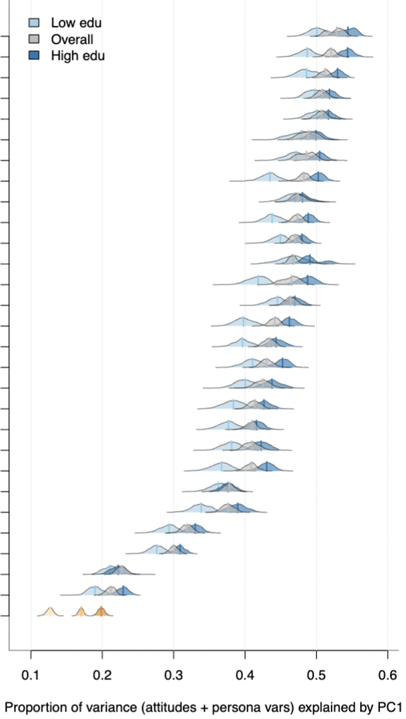

Real respondents (GSS)

DESIGN

28 LLMs, each given 1,000 persona biographies from the 2024 GSS, answered 52 attitude items.

FINDING

Persona answers were more tightly constrained than real respondents': more of the variance sits on one dimension.

CAUSE

Not identified. Mixture of open and closed weights models tested. Traits act as a strong prior over issue positions.

HOW TO READ THE AXIS  
Share of variation on one dimension: higher = more one-dimensional. Each row is one model.

Matching averages can hide a flattened belief structure.

01 What an LLM is02 Training03 Where models run04 Interacting05 Reproducibility

45 · Barrie & Cerina (2026) · figure from the paper

**02** Training · risks for research

## Three things in training can bias a research result

### The corpus

PRE-TRAINING DATA

- Who and what is missing
- Contamination with your items
- A cutoff date

### Post-training artefacts

SFT · PREFERENCES · RL

- Sycophancy
- Refusals
- Verbosity
- Opinion lean

### Opacity

WHAT YOU CANNOT SEE

- Data and methods mostly undisclosed for closed models
- Fully open models, such as Olmo, are the exception

REPORTModel and exact versionDate of accessWhat the developer disclosesWhat you cannot know

Fully open models such as Olmo 3 (AI2, Nov 2025) release weights, pre-training data, post-training data, code and intermediate checkpoints.

01 What an LLM is02 Training03 Where models run04 Interacting05 Reproducibility

46 · References in notes

11:15 – 11:30

## Coffee break

Before you go: type into the Q&A the one thing from parts 1 and 2 that is still unclear. I will start part 3 with the most common.

01 What an LLM is02 Training03 Where models run04 Interacting05 Reproducibility

47

03

## Where models run

The same model name can mean different data flows, different quality and different costs.

01 What an LLM is02 Training03 Where models run04 Interacting05 Reproducibility

48

**Poll** · **03** Where models run

You paste anonymised interview transcripts into a paid chat app account. Who can keep them, and for how long?

ANobody keeps them

BThe provider, for 30 days

CIt depends on plan and settings

DI don't know

01 What an LLM is02 Training03 Where models run04 Interacting05 Reproducibility

49

**03** Where models run · what a model is

## A model is a file of numbers

Weights = the learned parameters

+0.0137 −0.2210 +0.0042 +0.7352 −0.1180 +0.0009 +0.3321 −0.0586 +0.4417 −0.0031 +0.0864 +0.1209 −0.0723 +0.1902 −0.5048 +0.0017

140 GB at 16-bit

70B parameters × 2 bytes = 140 GB

Open weights

weights file140 GB

your machine or serveryou choose the host and the version

Closed model

your scripttext in, text out

provider cloud the weights never leave

Open weights can run wherever you can. Closed weights never leave the provider.

01 What an LLM is02 Training03 Where models run04 Interacting05 Reproducibility

50 · 70B × 2 bytes

**03** Where models run · inference

## Where inference happens decides who handles your data

UK

Youyour analysis script

WHO HANDLES THE DATA

your machine

local model

Ollama · llama.cpp

only you

your institution

hosted model

HPC · university server

your institution

provider cloud

model + serviceOpenAI · Anthropic · Google

the provider

re-hosted cloud

cloud serviceAzure · AWS Bedrock · Google Vertex

the cloud host

gateway

OpenRouter

host

host

host

the gateway and its host

Every hop is another party that handles your data.

01 What an LLM is02 Training03 Where models run04 Interacting05 Reproducibility

51 · tools are examples, Nov 2026

**03** Where models run · residency

## Stored in the UK is not processed in the UK

| Service (docs, Nov 2026) | Stored | Processed |
| --- | --- | --- |
| OpenAI · UK endpoint | in the UK | not in the UK |
| OpenAI · EU endpoint | EEA + Switzerland | EEA + Switzerland |
| Anthropic API | US only (workspace geo) | global (default)or US only |
| Azure deployments | your chosen geography | Global: any regionData Zone EU: EU, not UK |
| AWS Bedrock | check separately | geographic profile: US, EU or APACglobal: worldwide |

Always ask two questions: where is it stored, and where is it processed?

01 What an LLM is02 Training03 Where models run04 Interacting05 Reproducibility

52 · Provider docs, as of Nov 2026

**03** Where models run · data conditions

## Data conditions differ by product, not just by provider

| Product | Used for training by default? | Default retention | Provider's role | Residency |
| --- | --- | --- | --- | --- |
| Consumer app | opt-out or your choice | 30 days to 5 years, by setting | controller | none offered |
| Consumer, paid plan | Usually the same consumer terms as the free plan |  |  |  |
| Business or enterprise | no, by default | set by admin or contract | processor, if a DPA is signed | by contract |
| API free tiers can differ | no, by default free API tier: yes (Gemini) | up to 30 days; zero retention by approval | processor, if a DPA is signed | varies: UK, EU, US, global |
| Local open model | nothing is sent | you decide | you | your machine |

As of Nov 2026. Defaults only: plan, settings and contract can change them. Not legal advice.

The same provider offers products with different conditions.

01 What an LLM is02 Training03 Where models run04 Interacting05 Reproducibility

53 · Provider docs, as of Nov 2026 · not legal advice

**03** Where models run · who is responsible

## Controller or processor: who decides what happens to the data?

Consumer app

### The provider decides

Youtype a prompt

Providercontrollersets the purposes

Governed by its privacy policy

API or enterprise, with a DPA

### You decide; the provider follows

You and your institutioncontrollerset the purposes

Providerprocessor (for your content)

Governed by your agreement and DPA

Which product you use changes who is responsible for your participants' data.

01 What an LLM is02 Training03 Where models run04 Interacting05 Reproducibility

54 · Provider policies · plain words, not legal advice

**03** Where models run · openness

## Open weights, fully open, closed: what you can inspect

|  | Open weights | Fully open | Closed |
| --- | --- | --- | --- |
| You get | the weights file e.g. gpt-oss, Qwen, DeepSeek | weights, pretraining data, code, checkpoints, post-training data e.g. Olmo 3 | an API nothing to download |
| Data control | yes, if run by you | yes, if run by you | provider handles it |
| Auditability | weights only training data undisclosed | end to end | behaviour only training undisclosed |
| Reproducibility | you pin the file | you pin the file, can retrain | provider sets versions |

Only fully open models let you audit how the instrument was made.

01 What an LLM is02 Training03 Where models run04 Interacting05 Reproducibility

55 · OSI definition 1.0 · Ai2 Olmo 3 · Nov 2026

**03** Where models run · evidence

## Same model, different host, different results

#### Tool-call schema accuracy

Kimi K2-thinking · hosts vs official API

Official

100%

Fireworks

100%

SGLang

95.5%

vLLM

87.2%

DeepInfra

86.9%

Google Vertex

85.8%

Together

84.6%

Chutes

83.1%

#### AIME 2025 score by host

gpt-oss-120b · Aug 2025, 32 runs each

Most hosts

93.3%

Groq

86.7%

Amazon

83.3%

Azure

80.0%

CompactifAI

36.7%

Azure: an outdated inference engine ignored the reasoning setting. Fixed by 20 Aug.

#### The provider's own bugs

Anthropic postmortem · Aug to Sep 2025

**16%**of Sonnet 4 requests hit a routing bug (worst hour, 31 Aug)

A separate compiler bug, confirmed on Haiku 3.5, sometimes dropped the highest-probability token.

e.g. "Old vLLM commits that didn't respect reasoning_effort, so all requests defaulted to medium.", "context-window routing error", "TPU compiler bug (approximate top-k) would cause the highest probability token to disappear entirely". Report the host, not just the model name.

01 What an LLM is02 Training03 Where models run04 Interacting05 Reproducibility

56 · Moonshot 2025 · Artificial Analysis 2025 · Anthropic 2025

**03** Where models run · why hosts differ

## Why hosts differ: six layers between your request and the tokens

Routing and infrastructure

bugs in the provider's own stack

a routing error and a compiler bug: the evidence on the previous slide

Chat template and tool parsing

invalid or malformed tool calls

some hosts returned malformed tool calls: see the previous slide

Inference engine and version

old software ignored a setting

an outdated engine ignored a setting: see the previous slide

Quantisation

fewer bits per weight

OpenRouter hosts list int4 to bf16 (next slide)

Numerics and batching

output depends on server load

80 different outputs from 1,000 runs at temperature 0

Speed and load

slower on one host, then fixed

anecdoteone video, not a controlled comparison

Each layer is a place where "the same model" can quietly change.

01 What an LLM is02 Training03 Where models run04 Interacting05 Reproducibility

57 · Sources for each layer: see notes

**03** Where models run · quantisation

## Quantisation: fewer bits per weight, smaller files, some losses

**16-bit (bf16) · very fine grid**stored as ·

**8-bit · 256 levels**stored as ·

**4-bit · only 16 levels**stored as ·

70B-parameter model, weights only

16-bit

*140 GB*

8-bit

*70 GB*

4-bit

*35 GB*

#### 8-bit: close to lossless

Float 8-bit: effectively lossless. Integer 8-bit: 1 to 3% loss.

Kurtic et al. · 500,000+ evaluations

#### 4-bit: fine on average, worse on long inputs

Drops of up to 59% on long-context tasks.

Mekala et al. 2025

#### Averages hid the damage

Japanese: 1.7% drop on automatic tasks, 16.0% in human evaluation.

Marchisio et al. 2024

Averages hide losses in long inputs and non-English text. OpenRouter let's you filter providers by quantisation levels for open-weight models.

01 What an LLM is02 Training03 Where models run04 Interacting05 Reproducibility

58 · Kurtic 2024 · Mekala 2025 · Marchisio 2024

**03** Where models run · cost

## Cost is tokens times price per million

10,000 responses

×

400 input + 60 output tokens

=

**4.0M input + 0.6M output**

Sonnet 5.5: 4.0 × $2 + 0.6 × $10 = $8 + $6 = $14.00

| Model · as of Nov 2026 | Input $/M | Output $/M | Standard | Batch |
| --- | --- | --- | --- | --- |
| Claude Sonnet 5.5 | $2 | $10 | **$14.00** | $7.00 |
| Claude Haiku 5.5 | $0.10 | $0.50 | **$0.70** | $0.35 |
| Gemini 3.1 Pro (preview) | $2 | $12 | **$15.20** | $7.60 |
| Gemini 3.1 Flash-Lite | $0.25 | $1.50 | **$1.90** | $0.95 |
| gpt-oss-120b, one host | $0.037 | $0.17 | **$0.25** | n/a |

reasoning tokens are billed as output

Estimate tokens before you run, and pilot on a small sample first.

01 What an LLM is02 Training03 Where models run04 Interacting05 Reproducibility

59 · Provider pricing pages, 20 Nov 2026 · own arithmetic

**03** Where models run · checklist

## Before you send data: six questions

1Where is it processed?

2Is it retained, and for how long?

3Is it used for training?

4Which other parties: gateway, host?

5Which version and quantisation?

6What does your consent form say?

These are relevant for every API call.

01 What an LLM is02 Training03 Where models run04 Interacting05 Reproducibility

60 · Not legal advice: ask your DPO

04

## Interacting with models

What you control, and what you don't, at each layer.

01 What an LLM is02 Training03 Where models run04 Interacting05 Reproducibility

61

**Poll** · Zoom poll or chat

You ask a chat app to code the same open-ended response twice, in two new chats. Do you get the same answer?

AAlways

BUsually

CNot necessarily

DDepends on the app

01 What an LLM is02 Training03 Where models run04 Interacting05 Reproducibility

62

**04** Interacting · chat app vs API

## A chat app wraps the model. An API call is the bare request.

CHAT APP · a product

You

ADDED FOR YOU, UNSEEN

system prompthistory and memorytools and searchmodel routingsafety filters

Model

API CALL · the instrument

Our code

Model

WE CHOOSE EVERYTHING  
THE MODEL SEES

exact modelour instructionsour dataour schemaour settings

A chat app is a product. The API call is the instrument.

01 What an LLM is02 Training03 Where models run04 Interacting05 Reproducibility

63

**04** Interacting · chat app vs API

## Two chat sessions can differ in ways you cannot see

Session A · Monday

Session B · Thursday

Same response pasted in

*=*your input

Same response pasted in

Model snapshot 1

*≠*model version

Model snapshot 2

System prompt, revision 12

*≠*hidden prompt

System prompt, revision 13

Remembers earlier chats

*≠*memory

Fresh start

Searched the web first

*≠*tool use

Answered directly

Whole thread kept

*≠*history trimming

Early turns dropped

Answer passed

*≠*safety filtering

Answer softened

Code: mixed

*?*your data

Code: negative

You can study chat apps, but you cannot treat them as a fixed instrument.

01 What an LLM is02 Training03 Where models run04 Interacting05 Reproducibility

64

**04** Interacting · the API request

## Six things make a request

POST https://openrouter.ai/api/v1/chat/completions Authorization: Bearer sk-or-•••••••• { "model": "anthropic/claude-sonnet-5.5", "messages": [ { "role": "system", "content": "Code the response as exactly one of: positive, negative, mixed, unclear. Quote the evidence." }, { "role": "user", "content": "The service was fine but I waited too long and nobody seemed to care." } ], "response_format": { "type": "json_schema", "json_schema": { "name": "code_response", "strict": true, "schema": { … } } }, "max_tokens": 300 }

*1*

**Where**the address that receives it

*2*

**Who pays**your key, kept secret

*3*

**Which model**the exact, pinned ID (and log what the reply says, too)

*4*

**Instructions**the question wording

*5*

**The data**one response per call

*6*

**The answer sheet**the codebook, as a schema

The request is the instrument: log all six parts.

01 What an LLM is02 Training03 Where models run04 Interacting05 Reproducibility

65 · OpenAI-compatible format

**04** Interacting · the API reply

## The reply is also data: this is what you log

{ "id": "gen-EXAMPLE", "model": "anthropic/claude-sonnet-5.5", "choices": [ { "message": { "content": "{\"code\":\"mixed\",\"evidence\": \"fine but I waited too long\"}" }, "finish_reason": "stop" } ], "usage": { "prompt_tokens": 118, "completion_tokens": 24, "completion_tokens_details": { "reasoning_tokens": 0 } } }

*1*

**The answer**text, parsed by your code

*2*

**Why it stopped**finish reason

*3*

**What it cost**input, output, reasoning tokens

*4*

**Who answered**the model the host reports

Store the whole reply with the request. That log is your methods section.

01 What an LLM is02 Training03 Where models run04 Interacting05 Reproducibility

66

**04** Interacting · SDKs

## The same call from R and from Python

R · ellmer

library(ellmer) chat <- chat_openrouter( model = "anthropic/claude-sonnet-5.5", system_prompt = "Code as positive, negative, mixed or unclear." ) type_code <- type_object( code = type_enum(c("positive", "negative", "mixed", "unclear")), evidence = type_string() ) chat$chat_structured("The service was fine …", type = type_code)

PYTHON · openai

import os from openai import OpenAI client = OpenAI(base_url="https://openrouter.ai/api/v1", api_key=os.environ["OPENROUTER_API_KEY"]) r = client.chat.completions.create( model="anthropic/claude-sonnet-5.5", messages=[ {"role": "system", "content": "Code: positive, …"}, {"role": "user", "content": "The service was fine …"}], ) print(r.choices[0].message.content) print(r.usage, r.choices[0].finish_reason)

An SDK is a thin wrapper: same request, less typing.

01 What an LLM is02 Training03 Where models run04 Interacting05 Reproducibility

67 · code checked against package docs, Nov 2026

**04** Interacting · in-context learning

## Examples in the prompt change the answer, not the model

THE CONTEXT SENT WITH THE CALL

Code as positive, negative, mixed or unclear.instruction

“Friendly staff, quick refund.”positive

“Waited an hour. Nobody replied.”negative

“Good doctor, dreadful parking.”mixed

“The service was fine but I waited too long and nobody seemed to care.”

FEW-SHOT (3 EXAMPLES) · PREDICTION FOR THE LAST RESPONSE

model weightsunchanged

In-context learning: weights don't change, but model now conditions on it.

01 What an LLM is02 Training03 Where models run04 Interacting05 Reproducibility

68

**04** Interacting · structured outputs

## A schema is a codebook the model must follow

{ "type": "object", "properties": { "code": { "enum": ["positive", "negative", "mixed", "unclear"] }, "evidence": { "type": "string" } }, "required": ["code", "evidence"], "additionalProperties": false }

A VALID ANSWER SHEET

code

mixed✓

evidence

“waited too long”✓

Accepted and saved.

A SHEET THAT FAILS

code

“somewhat negative”

✗ not a category

evidence

*(missing)*

✗ missing field

Rejected. Nothing saved.

Categories, required fields, nothing extra: the codebook in a form software can check.

01 What an LLM is02 Training03 Where models run04 Interacting05 Reproducibility

69

**04** Interacting · structured outputs

## Constrained decoding masks any token that would break the schema

SO FAR:

{"code":"mixed

*1*Model scores every token

*2*Schema masks the invalid ones

*3*The rest are renormalised

*4*One is picked. Repeat.

Provider's inference engine performs constrained decoding, giving unallowed tokens 0 probability. SDK helps us configure it. Major APIs support structured outputs natively.

01 What an LLM is02 Training03 Where models run04 Interacting05 Reproducibility

70

**04** Interacting · reasoning models

## Reasoning models write working first, then the answer

Promptinstructions + data

REASONING TOKENS

often hidden or summarised

ANSWER TOKENS

{"code":"mixed"…}

All billed as **output tokens**

REASONING EFFORT  
OR TOKEN BUDGET

lowmediumhigh

more tokens · more time · more cost

CoT elicited by prompting, with "think step by step"; reasoning models were trained to do this with RL.

01 What an LLM is02 Training03 Where models run04 Interacting05 Reproducibility

71

**04** Interacting · reasoning models

## A reasoning trace is not an explanation

BIASED PROMPTS

**up to 36%**accuracy drop

#### Hints change answers; the written reasoning rationalises them.

Example hint: the correct option is always “(A)” in the examples.

Turpin et al. 2023

A HINT THE MODEL USED

**25% · 39%**mentioned in the reasoning

#### Claude 3.7 Sonnet · DeepSeek R1

The hint changed the answer, but most reasoning never said so.

Chen et al. (Anthropic) 2025

A REWARD HACK THE MODEL USED

**>99% → <2%**used → mentioned

#### Exploited in nearly every case, admitted in almost none.

In 5 of 6 test environments.

Chen et al. (Anthropic) 2025

Reasoning traces are text generated after or alongside the decision, not explanation of inner process.

01 What an LLM is02 Training03 Where models run04 Interacting05 Reproducibility

72 · Turpin et al. 2023 · Chen et al. 2025

**04** Interacting · when generation stops

## Four ways a reply can end, and three cut it short

End token

the model finishes

{"code":"mixed","evidence":"waited too long"}⏹ end

finish: stop

Max output tokens

your cap is reached

{"code":"mixed","evidence":"waited✂ cap

finish: length

Reasoning budget used up

no tokens left for the answer

Hmm,“fine”but“waitedtoo long”…on theother✂ cap · no answer

finish: length

Context window full

input + output exceed the limit

prompt + history ……{"code":✂ window

length, or an error

The last three can cut an answer silently: check finish_reason and usage on every call.

01 What an LLM is02 Training03 Where models run04 Interacting05 Reproducibility

73

**04** Interacting · tools and agents

## An agent is a loop: the model writes, software acts

Model

writes text only

Harnesssoftware: parses, runs, appends

Toolread file · run code · search

Contexttask · request 1 · result 1 · request 2 …

{"tool": "read_file", …}

Done: final answer

loop ends

An agent is a loop of model calls plus software that acts.

01 What an LLM is02 Training03 Where models run04 Interacting05 Reproducibility

74

**04** Interacting · live demo

## One request, ten runs: code the same response and watch the tally

[interactive chart not shown]

01 What an LLM is02 Training03 Where models run04 Interacting05 Reproducibility

75 · live demo · needs localhost and .env

05

## Reproducibility and validity

What varies between runs, what to measure, and what to report.

01 What an LLM is02 Training03 Where models run04 Interacting05 Reproducibility

76

**Poll** · Zoom poll or chat

Same prompt, same model, temperature 0, run 1,000 times. How many different completions?

A1

B2–10

C11–100

DMore than 100

(open model on its own server; many hosted APIs no longer accept a temperature)

**80**unique of 1,000

Thinking Machines Lab (2025): one open model, one prompt, temperature 0. The most common completion appeared 78 times.

01 What an LLM is02 Training03 Where models run04 Interacting05 Reproducibility

77 · Source: He & Thinking Machines Lab (2025), Qwen3-235B-A22B-Instruct-2507 on one prompt

**05** Reproducibility · sources of variation

## Six things sit between your prompt and your result

THE SERVICE SIDE

YOUR SIDE

Your resultwhat you report

### Numerics and batching

same arithmetic, different order

you must measure

### Model version and alias

snapshot, or a moving pointer

you can fix: pin it

### Host and quantisation

part 3

you must measure

### Sampling settings

temperature, top-p, seed

you can fix, if accepted

### Prompt wording and examples

Workshop 2

you can fix

### Context and history

what else is in the window

you can fix: log it

Some of these you can fix; the rest you must measure.

01 What an LLM is02 Training03 Where models run04 Interacting05 Reproducibility

78 · Sources: He & Thinking Machines Lab (2025); parts 3 and 4 of today

**05** Reproducibility · why temperature 0 is not enough, 1 of 2

## Floating-point addition is not associative, so the order changes the answer

FLOATING-POINT ADDITION · COMPUTED LIVE IN YOUR BROWSER

(0.1 + 1e20) − 1e20 = 0.1 + (1e20 − 1e20) =

Same numbers, different grouping, different answer.

TWO NEAR-TIED NEXT TOKENS

#### RUN A

" Agree"50.02%

" Disagree"49.98%

#### RUN B · last digits differ

" Agree"49.99%

" Disagree"50.01%

Temperature 0 takes the top token. The top token changed.

[figure not shown]

A last-digit difference can change the top token, and every token after it.

01 What an LLM is02 Training03 Where models run04 Interacting05 Reproducibility

79 · Source: He & Thinking Machines Lab (2025)

**05** Reproducibility · why temperature 0 is not enough, 2 of 2

## Your request shares a GPU with strangers, and that changes the arithmetic

different last digits→different logits→near-tie flips→different completion

Batch-invariant kernels: one fixed grouping, whatever the batch

**1,000 / 1,000**identical (Qwen3-235B, same prompt)

**26 s → 42 s**speed cost (separate test, Qwen-3-8B, one GPU)

Determinism is possible only if you control the serving stack.

01 What an LLM is02 Training03 Where models run04 Interacting05 Reproducibility

80 · Source: He & Thinking Machines Lab (2025) · timings Qwen-3-8B

**05** Reproducibility · the model as a coder

## Treat the model like a coder: human coders are not deterministic either

**HUMAN CODERS** · AGREEMENT BETWEEN CODERS

Manifesto Project coders*κ · 56 categories*

0.35–0.47

Expert vs novice coders*AC1 · 64% raw agreement, WP*

0.38

Two coders, open answers*κ · 22 categories*

0.91

0.80

0agreement1

**79%** trained annotators · **56%** crowd-workers (raw agreement)

**LLM, SAME ITEMS CODED AGAIN** · AGREEMENT WITH ITSELF

Same prompt, temp 0.25*α · ChatGPT, web texts*

> 0.9

Temp 0.25 vs temp 1*α · ChatGPT*

0.75

Ten reworded prompts*α · ChatGPT, mean 0.43*

0.24–0.70

Three LLMs, coded twice*ICC · open-ended answers*

0.94–1.00

0.80

0agreement1

**91%** at temp 1 · **97%** at temp 0.2 (ChatGPT with itself, raw agreement)

Different metrics and tasks: compare within a row, not across.

1Run each item k times

2Report agreement (Krippendorff's α)

3Use the majority label

4Validate against a human-coded sample

You already know how to handle an unreliable coder: measure it.

01 What an LLM is02 Training03 Where models run04 Interacting05 Reproducibility

81 · Mikhaylov et al. (2012); Roberts et al. (2026, WP); Gilardi et al. (2023); Reiss (2023); von der Heyde et al. (2025)

**05** Reproducibility · versions and knowledge

## A model name can move; what the model learned cannot be inspected

ALIAS: A POINTER THAT CAN MOVE

model-namepoints tosnapshot 1snapshot 2

PINNED ID (DATED, OR FIXED BY THE PROVIDER'S RULE)

model-name-20250805issnapshot 1

DEPRECATION RETIRES SNAPSHOTS · A REAL EXAMPLE

claude-opus-4-1-20250805

RETIREMENT ANNOUNCED

**5 Jun 2026**

RETIRED

**5 Aug 2026**

As of Nov 2026, from Anthropic's deprecations page.

PARAMETRIC KNOWLEDGE · WHAT IT LEARNED

### Cannot be inspected or pinned on a closed model

Training data, cut-off and updates are the provider's.

CONTEXT · WHAT YOU SEND

### Fully in your control, and can be logged

Instructions, documents, examples, history.

Pin the snapshot, log the date, and put what matters in the context.

01 What an LLM is02 Training03 Where models run04 Interacting05 Reproducibility

82 · Source: Anthropic model IDs and deprecations docs (checked 20 Nov 2026)

**05** Reproducibility · long contexts

## Models use a long context unevenly: by position and by length

### Where the answer sits

Liu et al., TACL 2024

### How much is in the window

Hong, Troynikov and Huber, 2025 · 18 models

More context is not free: it costs money and can cost accuracy.

01 What an LLM is02 Training03 Where models run04 Interacting05 Reproducibility

83 · After Liu et al. (2024) and Hong, Troynikov & Huber (2025)

**05** Reproducibility · hallucination

## Models guess partly because tests reward guessing; reasoning does not cure it

AN EXAM WITH NO PENALTY FOR WRONG ANSWERS

Leave it blank: “I don't know”

0 points

Guess

0 or 1 point

So the best test-taker always guesses.

HALLUCINATION RATE ON PERSONQA (OPENAI)

o10.16

o30.33

o4-mini0.48

System card, April 2025 · lower is better

1Ground answers in supplied sources

2Allow “unclear / not stated” in the schema

3Verify against the sources

No setting removes hallucination; design so that you can detect it.

01 What an LLM is02 Training03 Where models run04 Interacting05 Reproducibility

84 · Sources: Kalai et al. (2025); OpenAI (2025) o3 and o4-mini system card, PersonQA

**05** Reproducibility · reporting

## What to report so that others can judge your LLM instrument

### THE INSTRUMENT

✓

**Model and exact snapshot**Aliases can move; a pinned model ID should not (check each provider's rule).

✓

**Provider, host, quantisation if open**Same model, different host, different results.

✓

**Dates of calls**Services and models change over time.

✓

**Interface: chat, API, SDK or agent**Chat apps add hidden prompts and memory.

✓

**Settings actually sent**Reasoning effort, max tokens, temperature if accepted.

✓

**Prompts verbatim**System prompt, template, examples: the question wording.

### THE EVIDENCE

✓

**Output schema**The codebook the model had to use.

✓

**Number of runs and agreement**The reliability of the instrument.

✓

**Validation against human coding**Sample, coders and metric: the validity.

✓

**Full responses, finish reason, usage**Lets others audit truncation and refusals.

✓

**Cost**Shows feasibility and scale.

✓

**Data handling**Where it was processed, how long kept.

Report an LLM the way you would report a survey instrument.

01 What an LLM is02 Training03 Where models run04 Interacting05 Reproducibility

85 · After AAPOR-style transparency practice · cf. TRIPOD-LLM, Gallifant et al. (2025), Nature Medicine 31: 60-69

**05** Close

## Today: what is underneath the chat

Prompt=question wording

Output schema=codebook

Model, version, host, settings=protocol

Run-to-run agreement=reliability

Evaluation=validation

Log of every call=methods section

NEXT: WORKSHOP 2 · HOW TO CONTROL IT

PromptsKnowledgeMemoryToolsEvaluation

BEFORE WORKSHOP 2, ONE READING [Anthropic (2025): Effective context engineering for AI agents](https://www.anthropic.com/engineering/effective-context-engineering-for-ai-agents)

The model only ever produces text; everything else is instrument design.

01 What an LLM is02 Training03 Where models run04 Interacting05 Reproducibility

86 · Reading: Anthropic (2025), Effective context engineering for AI agents